# Epi Machine Learning Final Project

Sydney Ng UNI: sn2863

Due: Monday, April 19, 2021 at 5:00 PM

# Part 1: Dietary patterns using unsupervised analysis

### Question 1: Research Question

What are the patterns in dietary consumption during pregnancy in women and 3-4 years postnatal in children in the birth cohort study?

This is a **description** research question. A hierarchical clustering unsupervised algorithm is most appropriate here because I am most interested in examining the patterns in the dietary consumption features and understanding these clusters in terms of the inputs. This algorithm is relatively simple to visualize and interpret.

### Question 2: Implementing PCA & Hierarchical Clustering

```r
library(tidyverse)
library(caret)
library(rpart.plot)
library(Amelia)
library(cluster)
library(factoextra) #scree
library(ggbiplot) #ggbiplot

rm(list = ls())
load("./exposome.RData") # Load data using path of where file is stored
```

```r
diet_df <- read_csv("./diet_data.csv") %>% select(-ID)

# Centering and scaling is a good idea because the means and SDs do not seem similar
colMeans(diet_df, na.rm=TRUE)
```

```
##           h_bfdur_Ter     h_cereal_preg_Ter      h_dairy_preg_Ter
##            24.6368315            16.4967486            25.4822709
##   h_fastfood_preg_Ter       h_fish_preg_Ter      h_fruit_preg_Ter
##             0.7663407             3.2530028            13.1715282
##     h_legume_preg_Ter       h_meat_preg_Ter        h_veg_preg_Ter
##             1.8240642             8.2950615            11.1354671
##    hs_bakery_prod_Ter      hs_beverages_Ter      hs_break_cer_Ter
##             4.7032392             0.7155824             4.0522439
##          hs_dairy_Ter       hs_fastfood_Ter       hs_org_food_Ter
##            21.0619775             0.4236278             0.6535215
##      hs_proc_meat_Ter      hs_readymade_Ter    hs_total_bread_Ter
##             3.0348180             0.4200431            13.1436855
##   hs_total_cereal_Ter     hs_total_fish_Ter   hs_total_fruits_Ter
##            18.9031677             2.3301695            11.0017759
##   hs_total_lipids_Ter     hs_total_meat_Ter hs_total_potatoes_Ter
##             5.4387113             7.5018550             3.4580238
##   hs_total_sweets_Ter      hs_total_veg_Ter      hs_total_yog_Ter
##             6.6771950             7.5164214             5.5019007
```

```r
apply(diet_df, 2, sd, na.rm=TRUE)
```

```
##           h_bfdur_Ter     h_cereal_preg_Ter      h_dairy_preg_Ter
##            17.5136591            11.8766037            10.4896656
##   h_fastfood_preg_Ter       h_fish_preg_Ter      h_fruit_preg_Ter
##             0.3352034             1.7457759             7.7494082
##     h_legume_preg_Ter       h_meat_preg_Ter        h_veg_preg_Ter
##             0.9467660             4.0124155             6.6334134
##    hs_bakery_prod_Ter      hs_beverages_Ter      hs_break_cer_Ter
##             2.7849575             0.5053377             2.5986054
##          hs_dairy_Ter       hs_fastfood_Ter       hs_org_food_Ter
##            10.2239840             0.2054097             0.5261999
##      hs_proc_meat_Ter      hs_readymade_Ter    hs_total_bread_Ter
##             1.7556106             0.2443212             7.9460975
##   hs_total_cereal_Ter     hs_total_fish_Ter   hs_total_fruits_Ter
##             9.4366524             1.2484622             5.9573989
##   hs_total_lipids_Ter     hs_total_meat_Ter hs_total_potatoes_Ter
##             3.1019777             3.4848672             1.4967605
##   hs_total_sweets_Ter      hs_total_veg_Ter      hs_total_yog_Ter
##             3.4756043             3.4830804             3.1274662
```

```r
set.up.preprocess <- preProcess(diet_df, method = c("center", "scale"))

# Output pre-processed values
transformed_df <- predict(set.up.preprocess, diet_df)

# ----------------------------------------------------
# Implementing a PCA for feature selection
diet_pca <- prcomp( ~., data=transformed_df, center=TRUE, scale=TRUE,)
  # only the features we are interested in reducing, not the outcome

# Can compare sds used to scale with the sds above to ensure they are close.
diet_pca$scale
```

```
##           h_bfdur_Ter     h_cereal_preg_Ter      h_dairy_preg_Ter
##                     1                     1                     1
##   h_fastfood_preg_Ter       h_fish_preg_Ter      h_fruit_preg_Ter
##                     1                     1                     1
##     h_legume_preg_Ter       h_meat_preg_Ter        h_veg_preg_Ter
##                     1                     1                     1
##    hs_bakery_prod_Ter      hs_beverages_Ter      hs_break_cer_Ter
##                     1                     1                     1
##          hs_dairy_Ter       hs_fastfood_Ter       hs_org_food_Ter
##                     1                     1                     1
##      hs_proc_meat_Ter      hs_readymade_Ter    hs_total_bread_Ter
##                     1                     1                     1
##   hs_total_cereal_Ter     hs_total_fish_Ter   hs_total_fruits_Ter
##                     1                     1                     1
##   hs_total_lipids_Ter     hs_total_meat_Ter hs_total_potatoes_Ter
##                     1                     1                     1
##   hs_total_sweets_Ter      hs_total_veg_Ter      hs_total_yog_Ter
##                     1                     1                     1
```

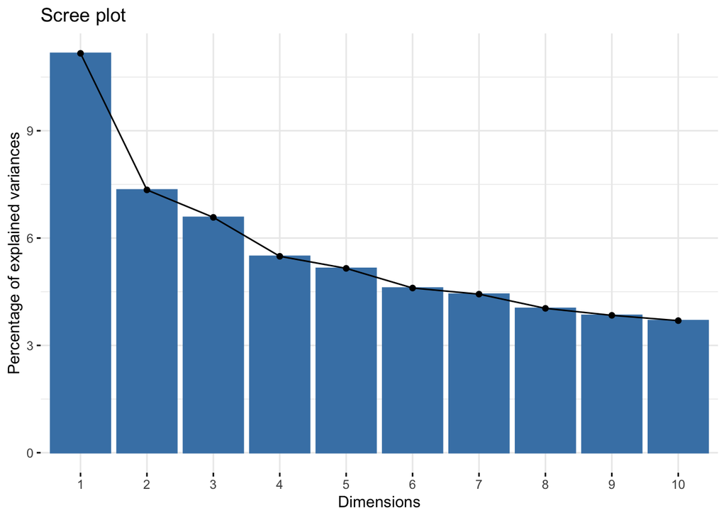

```r
# Generates scree plot
fviz_eig(diet_pca)
```

```r
# View results of pca. How many components are needed to explain at least 75% of the variance?
summary(diet_pca)
```

```
## Importance of components:
##                           PC1     PC2     PC3    PC4     PC5     PC6     PC7
## Standard deviation     1.7361 1.40835 1.33271 1.2175 1.17954 1.11490 1.09398
## Proportion of Variance 0.1116 0.07346 0.06578 0.0549 0.05153 0.04604 0.04433
## Cumulative Proportion  0.1116 0.18510 0.25088 0.3058 0.35731 0.40334 0.44767
##                            PC8    PC9    PC10    PC11    PC12    PC13    PC14
## Standard deviation     1.04377 1.0183 0.99844 0.97535 0.96525 0.94661 0.91970
## Proportion of Variance 0.04035 0.0384 0.03692 0.03523 0.03451 0.03319 0.03133
## Cumulative Proportion  0.48802 0.5264 0.56334 0.59858 0.63308 0.66627 0.69760
##                           PC15    PC16    PC17    PC18    PC19   PC20    PC21
## Standard deviation     0.91525 0.90937 0.89791 0.86389 0.84165 0.8331 0.81579
## Proportion of Variance 0.03103 0.03063 0.02986 0.02764 0.02624 0.0257 0.02465
## Cumulative Proportion  0.72863 0.75925 0.78911 0.81676 0.84299 0.8687 0.89334
##                           PC22    PC23    PC24    PC25    PC26    PC27
## Standard deviation     0.78527 0.77325 0.74673 0.65361 0.63380 0.52785
## Proportion of Variance 0.02284 0.02215 0.02065 0.01582 0.01488 0.01032
## Cumulative Proportion  0.91618 0.93833 0.95898 0.97480 0.98968 1.00000
```

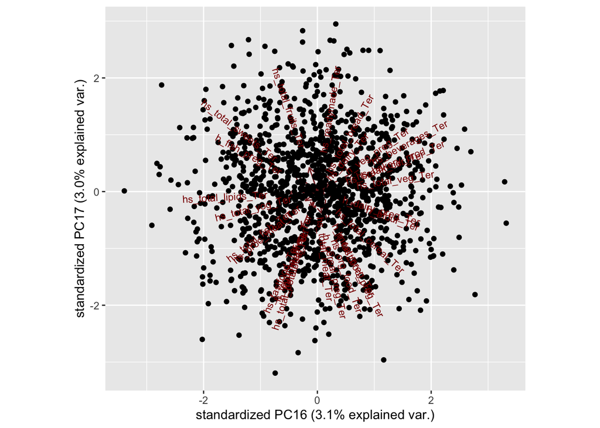

```r
  # we are more concerned with the cumulative proportion...
  # or can look at standard deviation -- cut off at 1

# Identify how features loaded on the different components
diet_pca_df <- diet_pca$rotation[,16] %>% as.data.frame() %>% filter(. >= 0.3| . <= -0.3)
ggbiplot(diet_pca, choices=c(16,17))
```

Checking the data, there are no missing values. I also noticed that the means and standard deviations for the numeric variables are not similar, so centering and scaling were performed.

Next, I ran a principal components analysis to perform feature selection to narrow down which of the 27 features to include in my hierarchical clustering algorithm. Upon inspection of the summary of the importance of components, I chose principal component 16 because it is the first to capture at least 75% of the variance in the outcome (“Cumulative Proportion”) and it has a decent standard deviation close to 1.

The features that the principal component are at least moderated correlated with from the original 27 and will be used for the unsupervised analysis are

- `h_bfdur_Ter`: duration of breastfeeding (weeks)
- `hs_beverages_Ter`: soda consumption; food group: beverages (hs_dietsoda + hs_soda)
- `hs_total_lipids_Ter`: food group: added fat

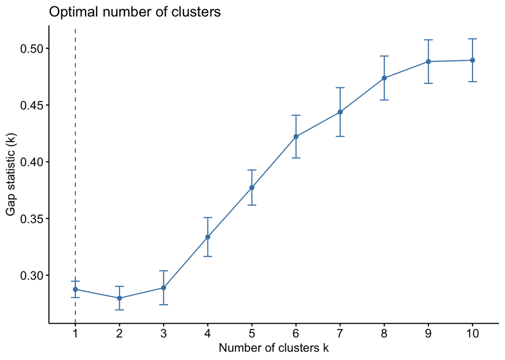

```r
# ----------------------------------------------------
# Implementing the hierarchical clustering
set.seed(100) # setting for replicability

clust_df <- transformed_df %>% select(h_bfdur_Ter, hs_beverages_Ter, hs_total_lipids_Ter)

# Create function to use within clusGap to identify the optimal number of clusters
hclusCut <-
  function(x, k) list(cluster = cutree(hclust(dist(x, method="euclidian"), method="complete"), k=k))
gap_stat <- clusGap(clust_df, # replace with PCA data frame here?
                    FUN = hclusCut, K.max = 10, B = 50)

fviz_gap_stat(gap_stat)
```

```r
clusters.hcut <- hcut(clust_df, k=4, hc_func="hclust", hc_method="complete", hc_metric="euclidian")
clusters.hcut$size
```

```
## [1] 238 212 386 465
```

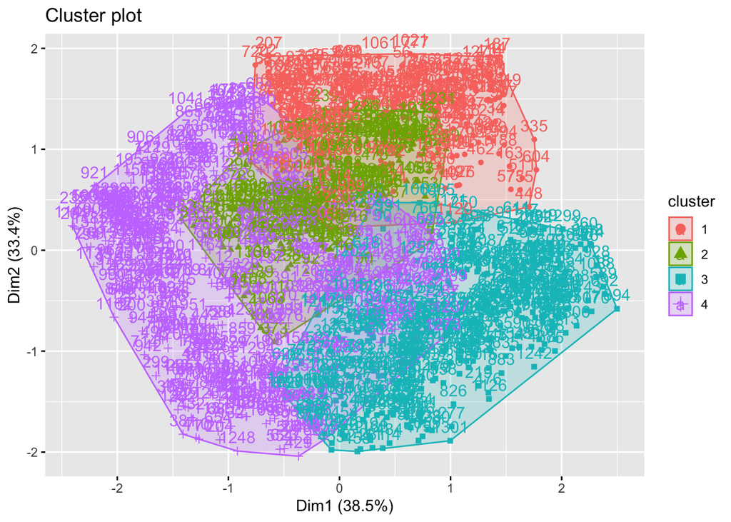

```r
# Visualizing the clusters (not using a dendogram due to the high number of observations)
fviz_cluster(clusters.hcut)
```

The hierarchical clustering algorithm identifies the optimal number of clusters to be 1. However, this is unhelpful and I chose a number of clusters 1 more than the next comparable number with a similar gap statistic, as shown in the gap statistic plot. Hence, I chose k = 4 clusters because this was the next number of clusters with a sharper increase in the gap statistic after k = 3, which was comparable to k = 1. After splitting up the observations into four clusters, the sizes of the clusters are 238, 212, 386, and 465.

### Question 3: Outputs

Describe the outputs of the analysis in terms of their composition of the input features.

```r
input.feature.vals <-
  bind_cols(diet_df, cluster=clusters.hcut$cluster)

input.feature.vals %>%
  group_by(cluster) %>%
  summarise_all(mean) %>%
  select(h_bfdur_Ter, hs_beverages_Ter, hs_total_lipids_Ter)
```

```
## # A tibble: 4 x 3
##   h_bfdur_Ter hs_beverages_Ter hs_total_lipids_Ter
##         <dbl>            <dbl>               <dbl>
## 1        9.20            1.28                 5.81
## 2        7.58            0.445                7.74
## 3       42.1             0.767                7.81
## 4       25.8             0.506                2.23
```

The unsupervised hierarchical clustering after running a PCA to perform feature selection returns four clusters:

- Cluster 1 has a mean weeks of breastfeeding of 9.20, the **highest** mean number of soda beverages of 1.28, and mean total added fats in diet of 5.81.
- Cluster 2 has the **lowest** mean weeks of breastfeeding at 7.58, the **lowest** mean number of soda beverages at 0.445, and a relatively high mean total of added fats at 7.74.
- Cluster 3 has the **highest** mean weeks of breastfeeding at 42.1, mean number of soda beverages of 0.767, and the **highest** mean total of added fats at 7.81.
- Cluster 4 has a relatively high mean number of weeks of breastfeeding at 25.8, a relatively low mean number of soda beverages at 0.506, and the **lowest** mean of total added fats in diet of 2.23.

# Part 2: Choose your own supervised adventure

### Research Question

What are the lifestyle and built environment features that best predict childhood obesity in children 6-11 years old?

My final project rationale is hypothesis generating about how lifestyle and built environment factors contribute to childhood obesity to inform future research on how individuals’ day-to-day surrounding built environments can interact with their lifestyles. I will be using a Random Forest for classification.

### Data cleaning, processing, and PCA

I will be using the results from my unsupervised analysis above to help inform the feature selection for the diet data. I will include the three identified by the PCA: `h_bfdur_Ter`, `hs_beverages_Ter`, and `hs_total_lipids_Ter` for all the diet features within the lifestyles group of features.

I will also run another principle components analysis to select from the other numeric features within the larger study data combining `exposome`, `phenotype`, and `covariates` datasets.

I created a new variable `pet_allergen` to replace the binary indicator features for having a dog, cat, or other pets. All other categorical variables are kept in the data as they were originally.

```r
studydata <- merge(exposome,phenotype,by="ID") %>%
  merge(covariates, by="ID") %>%
  mutate(hs_asthma = as.factor(hs_asthma)) %>%
  select(-ID)

builtenv_lifestyle_vars <-
  codebook %>% filter(family %in% c("Lifestyle", "Built environment")) %>% rownames()

builtenv_lifestyle <-
  studydata %>%
  select(builtenv_lifestyle_vars) %>%
  mutate(pet_allergen = # reducing dogs/cats/other pets to only having pets or not
           case_when(hs_pet_cat_r2_None == "0" ~ 0,
                     hs_pet_cat_r2_None == "1" ~ 1,
                     hs_pet_dog_r2_None == "0" ~ 0,
                     hs_pet_dog_r2_None == "1" ~ 1,
                     hs_pet_None == "No" ~ 0,
                     hs_pet_None == "Yes" ~ 1)) %>%
  select(-c(hs_pet_cat_r2_None, hs_pet_dog_r2_None, hs_pet_None)) %>%
  mutate(pet_allergen = as.factor(pet_allergen))

# ----------------------------------------------------
# Performing a PCA on the numeric variables
dat_num <- builtenv_lifestyle %>% select(where(is.numeric))
dat_not_num <- builtenv_lifestyle %>% select(!where(is.numeric))

# Centering and Scaling
set.up.preprocess <- preProcess(dat_num, method = c("center", "scale"))

# Output pre-processed values
transformed_nums <- predict(set.up.preprocess, dat_num)

# PCA
obesity_pca <- prcomp( ~., data=transformed_nums, center=TRUE, scale=TRUE,)

# Can compare sds used to scale with the sds above to ensure they are close.
obesity_pca$scale # checks out!
```

```
##   h_accesslines300_preg_dic0   h_accesspoints300_preg_Log
##                            1                            1
##     h_builtdens300_preg_Sqrt       h_connind300_preg_Sqrt
##                            1                            1
##       h_fdensity300_preg_Log     h_frichness300_preg_None
##                            1                            1
##   h_landuseshan300_preg_None          h_popdens_preg_Sqrt
##                            1                            1
## h_walkability_mean_preg_None     hs_accesslines300_h_dic0
##                            1                            1
##     hs_accesspoints300_h_Log       hs_builtdens300_h_Sqrt
##                            1                            1
##          hs_connind300_h_Log         hs_fdensity300_h_Log
##                            1                            1
##     hs_landuseshan300_h_None            hs_popdens_h_Sqrt
##                            1                            1
##   hs_walkability_mean_h_None     hs_accesslines300_s_dic0
##                            1                            1
##     hs_accesspoints300_s_Log       hs_builtdens300_s_Sqrt
##                            1                            1
##          hs_connind300_s_Log         hs_fdensity300_s_Log
##                            1                            1
##     hs_landuseshan300_s_None            hs_popdens_s_Sqrt
##                            1                            1
##               hs_KIDMED_None         hs_mvpa_prd_alt_None
##                            1                            1
##                hs_sd_wk_None      hs_dif_hours_total_None
##                            1                            1
```

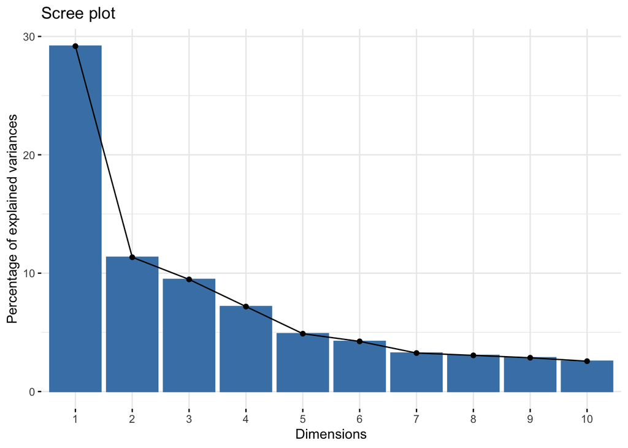

```r
# Generates scree plot
fviz_eig(obesity_pca)
```

```r
# View results of pca. How many components are needed to explain at least 75% of the variance?
summary(obesity_pca)
```

```
## Importance of components:
##                           PC1    PC2     PC3    PC4     PC5     PC6     PC7
## Standard deviation     2.8585 1.7823 1.62865 1.4179 1.16989 1.08923 0.95433
## Proportion of Variance 0.2918 0.1134 0.09473 0.0718 0.04888 0.04237 0.03253
## Cumulative Proportion  0.2918 0.4053 0.50000 0.5718 0.62068 0.66305 0.69558
##                            PC8     PC9    PC10    PC11   PC12    PC13    PC14
## Standard deviation     0.92505 0.89410 0.84760 0.83297 0.8231 0.73604 0.73454
## Proportion of Variance 0.03056 0.02855 0.02566 0.02478 0.0242 0.01935 0.01927
## Cumulative Proportion  0.72614 0.75469 0.78035 0.80513 0.8293 0.84867 0.86794
##                           PC15    PC16    PC17    PC18   PC19    PC20    PC21
## Standard deviation     0.70746 0.65409 0.61585 0.61268 0.5473 0.53816 0.52580
## Proportion of Variance 0.01788 0.01528 0.01355 0.01341 0.0107 0.01034 0.00987
## Cumulative Proportion  0.88582 0.90110 0.91464 0.92805 0.9387 0.94909 0.95896
##                          PC22    PC23    PC24    PC25    PC26    PC27    PC28
## Standard deviation     0.4764 0.46079 0.43149 0.41220 0.38668 0.32239 0.31658
## Proportion of Variance 0.0081 0.00758 0.00665 0.00607 0.00534 0.00371 0.00358
## Cumulative Proportion  0.9671 0.97465 0.98130 0.98737 0.99271 0.99642 1.00000
```

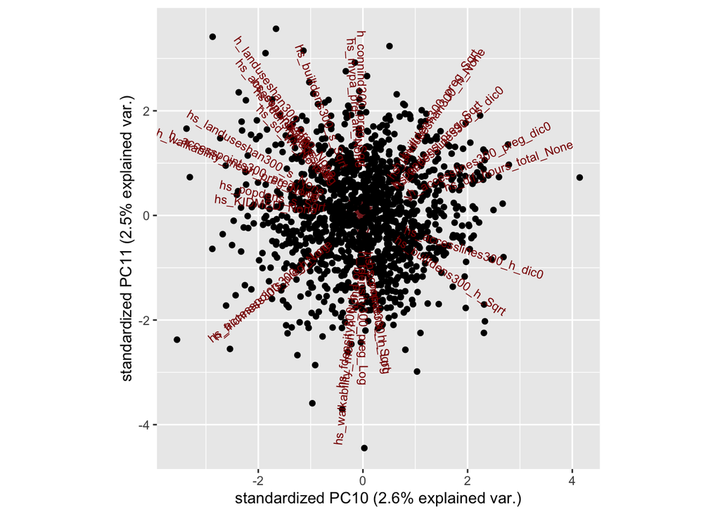

```r
obesity_pca_df <- obesity_pca$rotation[,10] %>% as.data.frame() %>% filter(. >= 0.3| . <= -0.3)
ggbiplot(obesity_pca, choices=c(10,11))
```

```r
pca_vars <- dat_num %>% select(hs_KIDMED_None, hs_sd_wk_None, hs_dif_hours_total_None)
cat_vars <- dat_not_num %>% select(h_bfdur_Ter, hs_beverages_Ter, hs_total_lipids_Ter,
                                   pet_allergen, e3_alcpreg_yn_None, h_folic_t1_None,
                                   h_pavig_t3_None, h_pamod_t3_None, hs_caff_drink_Ter)

# Creating final set of data to work with
obesity_df <- bind_cols(pca_vars, cat_vars) # from 241 to 12 variables!
colnames(obesity_df)
```

```
##  [1] "hs_KIDMED_None"          "hs_sd_wk_None"
##  [3] "hs_dif_hours_total_None" "h_bfdur_Ter"
##  [5] "hs_beverages_Ter"        "hs_total_lipids_Ter"
##  [7] "pet_allergen"            "e3_alcpreg_yn_None"
##  [9] "h_folic_t1_None"         "h_pavig_t3_None"
## [11] "h_pamod_t3_None"         "hs_caff_drink_Ter"
```

- `hs_KIDMED_None`: sum of KIDMED indices, without index 9 postnatal
- `hs_sd_wk_None`: sedentary behaviour (min/day) postnatal
- `hs_dif_hours_total_None`: total hours of sleep (mean weekdays and night) postnatal

Furthermore, of the 33 categorical lifestyle and built environment features in the study data, I am including the following diet variables from the previous unsupervised PCA

- `h_bfdur_Ter`: duration of breastfeeding (weeks)
- `hs_beverages_Ter`: soda consumption; food group: beverages (hs_dietsoda + hs_soda)
- `hs_total_lipids_Ter`: food group: added fat,

on top of the other categorical variables in the dataset:

- `pet_allergen`: a variable I created to indicate whether or not there are pets in the household
- `e3_alcpreg_yn_None`: alcohol during pregnancy (binarized: 0 = none or <1/m for KANC)
- `h_folic_t1_None`: folic acid supplementation during pregnancy
- `h_pavig_t3_None`: exercise or sport activity during pregnancy (frequency)
- `h_pamod_t3_None`: walking and/or cycling acitivity during pregnancy (frequency)
- `hs_caff_drink_Ter`: drinks a caffeinated or energy drink (e.g., Coca-cola, Diet-Coke, RedBull)

**Data Preparation**

```r
set.seed(100)
hs_bmi_c_cat <- studydata$hs_bmi_c_cat %>% as.data.frame()
rf_df <-
  bind_cols(obesity_df, hs_bmi_c_cat) %>%
  mutate(obesity = as.factor(ifelse(. == 4, 1,0))) %>% # binarizing BMI to obese or not
  select(-.)

# Checking the frequency for any imbalance reveals there is an imbalance in our outcome
summary(rf_df$obesity)
```

```
##    0    1
## 1170  131
```

BMI categories are binarized using obese or not obese levels. After checking for imbalances in the outcome, we can see that 1) there are no missing data and 2) 89.93% of the observations are classified as not obese and 10.07% of the observations are indeed obese.

**Splitting the testing and training data**

```r
set.seed(100)
train_indices <- createDataPartition(y=rf_df$obesity, p=0.7, list=FALSE)
training <- rf_df[train_indices, ] %>% tibble()
testing <- rf_df[-train_indices, ] %>% tibble()

# Checking distribution of the outcome -- we are good!
summary(training$obesity)
```

```
##   0   1
## 819  92
```

```r
summary(testing$obesity)
```

```
##   0   1
## 351  39
```

### Implementing Logistic Regression with Elastic-Net Regularization

```r
# ----------------------------------------------------
# Running an elastic net (regularized) logistic regression to predict childhood obesity status
train_control <- trainControl(method="cv", number = 10, sampling = "down")
logistic_reg <- train(obesity ~., data = training,
                      method = "glmnet", family = "binomial",
                      trControl = train_control, tuneLength=10)
logistic_reg$bestTune
```

```
##    alpha     lambda
## 72   0.9 0.04081648
```

Down-sampling was used in order to account for the imbalance in our outcome of obesity in the data. After performing a logistic regression with elastic net regularization, it turns out that the best tuning parameters for alpha and lambda are 0.9 and 0.0408165, respectively.

**Elastic-Net Results and Predictions**

```r
# Coefficients for the regularized logistic regression
coef(logistic_reg$finalModel, logistic_reg$bestTune$lambda)
```

```
## 19 x 1 sparse Matrix of class "dgCMatrix"
##                                        1
## (Intercept)                   4.23994035
## hs_KIDMED_None                .
## hs_sd_wk_None                 .
## hs_dif_hours_total_None      -0.42004672
## h_bfdur_Ter(10.8,34.9]        0.08454750
## h_bfdur_Ter(34.9,Inf]        -0.18174597
## hs_beverages_Ter(0.132,1]     .
## hs_beverages_Ter(1,Inf]       .
## hs_total_lipids_Ter(3,7]      .
## hs_total_lipids_Ter(7,Inf]   -0.32641356
## pet_allergen1                 .
## e3_alcpreg_yn_None1           .
## h_folic_t1_None1              0.28860349
## h_pavig_t3_NoneLow            .
## h_pavig_t3_NoneMedium         .
## h_pamod_t3_NoneOften          .
## h_pamod_t3_NoneSometimes      0.07624354
## h_pamod_t3_NoneVery Often     .
## hs_caff_drink_Ter(0.132,Inf]  .
```

```r
# Making predictions
logistic_pred <- logistic_reg %>% predict(training)

# Confusion Matrix
confusion_logistic <-
  confusionMatrix(logistic_pred, training$obesity,
                  positive = "1")
confusion_logistic$table
```

```
##           Reference
## Prediction   0   1
##          0 511  29
##          1 308  63
```

After applying this logistic regression model using regularization to the training dataset, we find that it is 63.01% accurate in predicting childhood obesity status, with a sensitivity and specificity of 68.48% and 62.39%, respectively.